# Analysis of Variance: MANOVA

If there is more than one dependent (outcome) variable, you can test them simultaneously using a Multivariate Analysis of Variance (MANOVA).

### Example Based on `UScereal` Dataset

The following example is based on the `UScereal` dataset in the `MASS` package [Venables & Ripley (1999)].

- We’re interested in whether the calories, fat, and sugar content of US cereals vary by store shelf, where 1 is the bottom shelf, 2 is the middle shelf, and 3 is the top shelf.
- Calories, fat, and sugars are the dependent variables, and shelf is the independent variable with three levels (1, 2, and 3).

Check the dataset

- The `aggregate()` function provides the shelf means.
- The `cov()` function provides the variance and the covariances across cereals.
- The `cor()` function provides pairwise correlation across cereals.

```r
library(MASS)
attach(UScereal)
y <- cbind(calories,fat,sugars)
aggregate(y,by=list(shelf),FUN=mean)
```

```
##   Group.1 calories       fat    sugars
## 1       1 119.4774 0.6621338  6.295493
## 2       2 129.8162 1.3413488 12.507670
## 3       3 180.1466 1.9449071 10.856821
```

```r
cov(y)
```

```
##            calories       fat     sugars
## calories 3895.24210 60.674383 180.380317
## fat        60.67438  2.713399   3.995474
## sugars    180.38032  3.995474  34.050018
```

```r
cor(y)
```

```
##           calories       fat    sugars
## calories 1.0000000 0.5901757 0.4952942
## fat      0.5901757 1.0000000 0.4156740
## sugars   0.4952942 0.4156740 1.0000000
```

The `manova()` function provides the multivariate test of group differences.

```r
fit <- manova(y~shelf)
summary(fit)
```

```
##           Df  Pillai approx F num Df den Df  Pr(>F)
## shelf      1 0.19594    4.955      3     61 0.00383 **
## Residuals 63
## ---
## Signif. codes:  0 '***' 0.001 '**' 0.01 '*' 0.05 '.' 0.1 ' ' 1
```

The significant F value indicates that the three groups differ on the set of nutritional measures.

Because the multivariate test is significant, you can use the `summary.aov()` function to obtain the univariate one-way ANOVAs. Here, you see that the three groups differ on each nutritional measure considered separately.

```r
summary.aov(fit)
```

```
##  Response calories :
##             Df Sum Sq Mean Sq F value    Pr(>F)
## shelf        1  45313   45313  13.995 0.0003983 ***
## Residuals   63 203982    3238
## ---
## Signif. codes:  0 '***' 0.001 '**' 0.01 '*' 0.05 '.' 0.1 ' ' 1
##
##  Response fat :
##             Df  Sum Sq Mean Sq F value   Pr(>F)
## shelf        1  18.421 18.4214   7.476 0.008108 **
## Residuals   63 155.236  2.4641
## ---
## Signif. codes:  0 '***' 0.001 '**' 0.01 '*' 0.05 '.' 0.1 ' ' 1
##
##  Response sugars :
##             Df  Sum Sq Mean Sq F value  Pr(>F)
## shelf        1  183.34  183.34   5.787 0.01909 *
## Residuals   63 1995.87   31.68
## ---
## Signif. codes:  0 '***' 0.001 '**' 0.01 '*' 0.05 '.' 0.1 ' ' 1
```

```r
fit.aov1 <- aov(calories~as.factor(shelf),data=UScereal)
fit.aov2 <- aov(fat~as.factor(shelf),data=UScereal)
fit.aov3 <- aov(sugars~as.factor(shelf),data=UScereal)
summary(fit.aov1)
```

```
##                  Df Sum Sq Mean Sq F value   Pr(>F)
## as.factor(shelf)  2  50435   25218   7.862 0.000905 ***
## Residuals        62 198860    3207
## ---
## Signif. codes:  0 '***' 0.001 '**' 0.01 '*' 0.05 '.' 0.1 ' ' 1
```

```r
summary(fit.aov2)
```

```
##                  Df Sum Sq Mean Sq F value Pr(>F)
## as.factor(shelf)  2  18.44   9.220   3.683 0.0308 *
## Residuals        62 155.22   2.504
## ---
## Signif. codes:  0 '***' 0.001 '**' 0.01 '*' 0.05 '.' 0.1 ' ' 1
```

```r
summary(fit.aov3)
```

```
##                  Df Sum Sq Mean Sq F value  Pr(>F)
## as.factor(shelf)  2  381.3   190.7   6.575 0.00257 **
## Residuals        62 1797.9    29.0
## ---
## Signif. codes:  0 '***' 0.001 '**' 0.01 '*' 0.05 '.' 0.1 ' ' 1
```

Finally, you can use a mean comparison procedure (such as `TukeyHSD`) to determine which shelves differ from each other for each of the three dependent variables.

```r
TukeyHSD(fit.aov1)
```

```
##   Tukey multiple comparisons of means
##     95% family-wise confidence level
##
## Fit: aov(formula = calories ~ as.factor(shelf), data = UScereal)
##
## $`as.factor(shelf)`
##         diff        lwr       upr     p adj
## 2-1 10.33877 -34.992274  55.66981 0.8480503
## 3-1 60.66917  19.862551 101.47579 0.0019863
## 3-2 50.33040   9.523785  91.13702 0.0118943
```

```r
TukeyHSD(fit.aov2)
```

```
##   Tukey multiple comparisons of means
##     95% family-wise confidence level
##
## Fit: aov(formula = fat ~ as.factor(shelf), data = UScereal)
##
## $`as.factor(shelf)`
##          diff        lwr      upr     p adj
## 2-1 0.6792150 -0.5872478 1.945678 0.4073504
## 3-1 1.2827733  0.1427142 2.422832 0.0237977
## 3-2 0.6035583 -0.5365008 1.743617 0.4166462
```

```r
TukeyHSD(fit.aov3)
```

```
##   Tukey multiple comparisons of means
##     95% family-wise confidence level
##
## Fit: aov(formula = sugars ~ as.factor(shelf), data = UScereal)
##
## $`as.factor(shelf)`
##          diff        lwr       upr     p adj
## 2-1  6.212177  1.9019469 10.522406 0.0027823
## 3-1  4.561328  0.6812951  8.441360 0.0173263
## 3-2 -1.650849 -5.5308815  2.229183 0.5661137
```

### Example Based on `iris` Dataset

```r
# Store the data in the variable data.iris
data.iris <- iris
head(data.iris)
```

```
##   Sepal.Length Sepal.Width Petal.Length Petal.Width Species
## 1          5.1         3.5          1.4         0.2  setosa
## 2          4.9         3.0          1.4         0.2  setosa
## 3          4.7         3.2          1.3         0.2  setosa
## 4          4.6         3.1          1.5         0.2  setosa
## 5          5.0         3.6          1.4         0.2  setosa
## 6          5.4         3.9          1.7         0.4  setosa
```

```r
library(ggpubr)
```

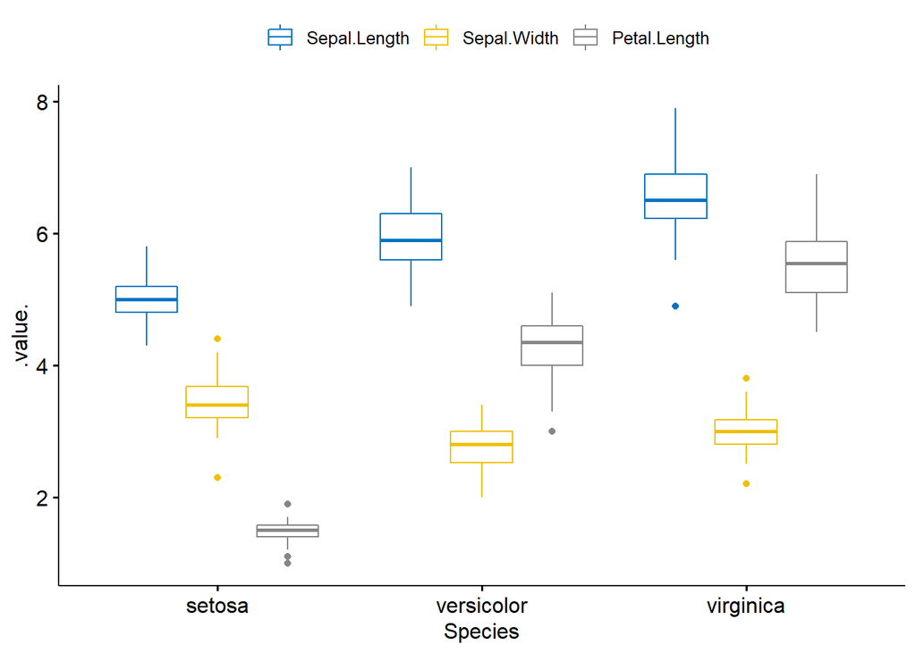

```r
ggboxplot(
  data.iris, x = "Species", y = c("Sepal.Length","Sepal.Width", "Petal.Length"),
  merge = TRUE, palette = "jco"
  )
```

```r
# MANOVA test
fit.iris <- manova(cbind(Sepal.Length, Petal.Length) ~ Species, data = data.iris)
summary(fit.iris)
```

```
##            Df Pillai approx F num Df den Df    Pr(>F)
## Species     2 0.9885   71.829      4    294 < 2.2e-16 ***
## Residuals 147
## ---
## Signif. codes:  0 '***' 0.001 '**' 0.01 '*' 0.05 '.' 0.1 ' ' 1
```

```r
# Look to see which differ
summary.aov(fit.iris)
```

```
##  Response Sepal.Length :
##              Df Sum Sq Mean Sq F value    Pr(>F)
## Species       2 63.212  31.606  119.26 < 2.2e-16 ***
## Residuals   147 38.956   0.265
## ---
## Signif. codes:  0 '***' 0.001 '**' 0.01 '*' 0.05 '.' 0.1 ' ' 1
##
##  Response Petal.Length :
##              Df Sum Sq Mean Sq F value    Pr(>F)
## Species       2 437.10 218.551  1180.2 < 2.2e-16 ***
## Residuals   147  27.22   0.185
## ---
## Signif. codes:  0 '***' 0.001 '**' 0.01 '*' 0.05 '.' 0.1 ' ' 1
```